# Projekt metody walidacji modeli statystycznych

Julia Hryciuk

# Cel projektu

Celem projektu jest zbudowanie modelu predykcyjnego, który na podstawie warunków i okoliczności zdarzenia drogowego przewiduje, jakiego rodzaju najcięższe obrażenia odniosą uczestnicy tego zdarzenia.

## Opis problemu

Model ma przewidywać jedną z poniższych klas obrażeń:

- **Brak obrażeń**
- **Nieunieruchamiające obrażenia**
- **Zgłoszone, niewidoczne**
- **Unieruchamiające obrażenia**
- **Śmiertelne**

## Znaczenie problemu

Wypadki drogowe to częsty i poważny problem. Niektóre z nich kończą się tylko stłuczką, ale inne prowadzą do poważnych obrażeń lub śmierci. Gdyby dało się wcześniej ocenić, które sytuacje są najbardziej ryzykowne, można byłoby lepiej się przygotować – np. zwiększyć czujność w danych warunkach, poprawić infrastrukturę albo szybciej wysłać pomoc. Taki model może wspierać służby ratunkowe, planowanie prewencji i zwiększać bezpieczeństwo na drogach.

## Opis zbioru danych

Dane wykorzystane w projekcie pochodzą ze zbioru dotyczącego wypadków drogowych pozyskanego z Kaggle . Każdy rekord odpowiada jednemu zdarzeniu i zawiera informacje opisujące jego charakter, warunki zewnętrzne oraz skutki.

### Najważniejsze zmienne w zbiorze danych

- **`crash_date`** – data wystąpienia wypadku
- **`traffic_control_device`** – rodzaj urządzenia sterującego ruchem (np. sygnalizacja świetlna, znak STOP)
- **`weather_condition`** – warunki pogodowe w momencie zdarzenia (np. deszcz, śnieg, dobra pogoda)
- **`lighting_condition`** – warunki oświetleniowe (np. dzień, noc, zmierzch)
- **`first_crash_type`** – typ pierwszego zdarzenia/zderzenia (np. najechanie, kolizja boczna)
- **`trafficway_type`** – typ drogi, na której doszło do wypadku (np. droga lokalna, autostrada)
- **`roadway_surface_cond`** – stan nawierzchni drogi (np. sucha, mokra, śliska)
- **`crash_type`** – ogólny typ wypadku (np. kolizja, potrącenie)
- **`damage`** – zakres uszkodzeń pojazdów
- **`prim_contributory_cause`** – główna przyczyna wypadku (np. błąd kierowcy, nadmierna prędkość)
- **`num_units`** – liczba jednostek uczestniczących w zdarzeniu (zwykle pojazdów)
- **`most_severe_injury`** – najcięższe obrażenia, jakie wystąpiły w danym zdarzeniu – to **zmienna celu**
- **`injuries_total`** – całkowita liczba osób rannych
- **`crash_hour`**, **`crash_day_of_week`**, **`crash_month`** – czasowe aspekty zdarzenia (godzina, dzień tygodnia, miesiąc)

# Eksploracja i charakterystyka danych

# Przygotowanie danych

Dane zostały wczytane i wstępnie przygotowane do analizy. Aby ułatwić analizę oraz późniejszą prezentację, wszystkie kolumny oraz kluczowe kategorie zmiennych zostały przetłumaczone na język polski. Dane mają strukturę typową dla analizy predykcyjnej – zawierają zmienną celu (najciezsze_obrazenia) oraz wiele potencjalnych predyktorów opisujących warunki, infrastrukturę, okoliczności i skutki wypadku.

# Eksploracja i charakterystyka danych

```
## Rows: 209,306
## Columns: 24
## $ data_zdarzenia                       <chr> "07/29/2023 01:00:00 PM", "08/13/…
## $ urzadzenie_sterujace_ruch            <chr> "Sygnalizacja świetlna", "Sygnali…
## $ warunki_pogodowe                     <chr> "Ładna pogoda", "Ładna pogoda", "…
## $ warunki_oswietlenia                  <chr> "Dzień", "Noc – droga oświetlona"…
## $ typ_pierwszego_zdarzenia             <chr> "Skręt", "Skręt", "Na tył", "Pod …
## $ typ_drogi                            <chr> "Jednopasmowa", "Skrzyżowanie czt…
## $ uklad_drogi                          <chr> "Prosta i płaska", "Prosta i płas…
## $ stan_nawierzchni                     <chr> "Nieznana", "Sucha", "Sucha", "Su…
## $ usterka_drogi                        <chr> "Nieznana", "Brak usterek", "Brak…
## $ typ_wypadku                          <chr> "Brak obrażeń / odjechanie z miej…
## $ czy_skrzyzowanie                     <chr> "Tak", "Tak", "Tak", "Tak", "Tak"…
## $ szkoda                               <chr> "501 – 1500 USD", "Powyżej 1500 U…
## $ glowna_przyczyna                     <chr> "Nieustalone", "Nieprawidłowy skr…
## $ liczba_pojazdow                      <int> 2, 2, 3, 2, 2, 1, 2, 2, 2, 2, 1, …
## $ najciezsze_obrazenia                 <chr> "Brak obrażeń", "Brak obrażeń", "…
## $ liczba_obrazen_calkowita             <dbl> 0, 0, 0, 5, 0, 2, 0, 1, 0, 0, 0, …
## $ liczba_ofiar_smierc                  <dbl> 0, 0, 0, 0, 0, 0, 0, 0, 0, 0, 0, …
## $ liczba_obrazen_unieruchamiajacych    <dbl> 0, 0, 0, 0, 0, 0, 0, 0, 0, 0, 0, …
## $ liczba_obrazen_nieunieruchamiajacych <dbl> 0, 0, 0, 5, 0, 2, 0, 1, 0, 0, 0, …
## $ liczba_obrazen_niewidocznych         <dbl> 0, 0, 0, 0, 0, 0, 0, 0, 0, 0, 0, …
## $ liczba_obrazen_brak_wskazan          <dbl> 3, 2, 3, 0, 3, 0, 2, 1, 3, 4, 1, …
## $ godzina_wypadku                      <int> 13, 0, 10, 19, 14, 0, 11, 14, 18,…
## $ dzien_tygodnia                       <int> 7, 1, 5, 4, 7, 4, 3, 4, 2, 5, 5, …
## $ miesiac                              <int> 7, 8, 12, 8, 8, 9, 12, 9, 6, 9, 9…
```

Data summary

| Name | data |
| --- | --- |
| Number of rows | 209306 |
| Number of columns | 24 |
| _______________________ |  |
| Column type frequency: |  |
| character | 14 |
| numeric | 10 |
| ________________________ |  |
| Group variables | None |

**Variable type: character**

| skim_variable | n_missing | complete_rate | min | max | empty | n_unique | whitespace |
| --- | --- | --- | --- | --- | --- | --- | --- |
| data_zdarzenia | 0 | 1 | 22 | 22 | 0 | 189087 | 0 |
| urzadzenie_sterujace_ruch | 0 | 1 | 4 | 28 | 0 | 19 | 0 |
| warunki_pogodowe | 0 | 1 | 4 | 23 | 0 | 12 | 0 |
| warunki_oswietlenia | 0 | 1 | 4 | 25 | 0 | 6 | 0 |
| typ_pierwszego_zdarzenia | 0 | 1 | 5 | 37 | 0 | 18 | 0 |
| typ_drogi | 0 | 1 | 5 | 31 | 0 | 20 | 0 |
| uklad_drogi | 0 | 1 | 14 | 30 | 0 | 6 | 0 |
| stan_nawierzchni | 0 | 1 | 4 | 24 | 0 | 7 | 0 |
| usterka_drogi | 0 | 1 | 4 | 19 | 0 | 7 | 0 |
| typ_wypadku | 0 | 1 | 25 | 35 | 0 | 2 | 0 |
| czy_skrzyzowanie | 0 | 1 | 3 | 3 | 0 | 2 | 0 |
| szkoda | 0 | 1 | 10 | 16 | 0 | 3 | 0 |
| glowna_przyczyna | 0 | 1 | 11 | 44 | 0 | 40 | 0 |
| najciezsze_obrazenia | 0 | 1 | 10 | 29 | 0 | 5 | 0 |

**Variable type: numeric**

| skim_variable | n_missing | complete_rate | mean | sd | p0 | p25 | p50 | p75 | p100 | hist |
| --- | --- | --- | --- | --- | --- | --- | --- | --- | --- | --- |
| liczba_pojazdow | 0 | 1 | 2.06 | 0.40 | 1 | 2 | 2 | 2 | 11 | ▇▁▁▁▁ |
| liczba_obrazen_calkowita | 0 | 1 | 0.38 | 0.80 | 0 | 0 | 0 | 1 | 21 | ▇▁▁▁▁ |
| liczba_ofiar_smierc | 0 | 1 | 0.00 | 0.05 | 0 | 0 | 0 | 0 | 3 | ▇▁▁▁▁ |
| liczba_obrazen_unieruchamiajacych | 0 | 1 | 0.04 | 0.23 | 0 | 0 | 0 | 0 | 7 | ▇▁▁▁▁ |
| liczba_obrazen_nieunieruchamiajacych | 0 | 1 | 0.22 | 0.61 | 0 | 0 | 0 | 0 | 21 | ▇▁▁▁▁ |
| liczba_obrazen_niewidocznych | 0 | 1 | 0.12 | 0.45 | 0 | 0 | 0 | 0 | 15 | ▇▁▁▁▁ |
| liczba_obrazen_brak_wskazan | 0 | 1 | 2.24 | 1.24 | 0 | 2 | 2 | 3 | 49 | ▇▁▁▁▁ |
| godzina_wypadku | 0 | 1 | 13.37 | 5.60 | 0 | 9 | 14 | 17 | 23 | ▂▅▅▇▅ |
| dzien_tygodnia | 0 | 1 | 4.14 | 1.97 | 1 | 2 | 4 | 6 | 7 | ▆▃▃▃▇ |
| miesiac | 0 | 1 | 6.77 | 3.43 | 1 | 4 | 7 | 10 | 12 | ▆▅▅▅▇ |

Zbiór danych zawiera 209.306 obserwacji i 24 zmienne, w tym: 14 zmiennych tekstowych i 10 zmiennych liczbowych.

Dane obejmują szczegóły dotyczące:

- warunków pogodowych i oświetleniowych,
- typu drogi, nawierzchni i obecności usterek,
- liczby obrażeń, pojazdów, godzin i dni zdarzenia.
- Zmienna docelowa `najciezsze_obrazenia` opisuje typ najcięższych obrażeń – to kluczowy cel modelowania i analizy skutków.

Wszystkie kolumny są kompletne, nie wystepują braki danych (100% uzupełnienia).

Podstawowe statystyki dla zmiennych liczbowych

| Zmienna | Średnia | Odch_std | Min | Mediana | Max |
| --- | --- | --- | --- | --- | --- |
| Liczba pojazdów | 2.06 | 0.40 | 1 | 2 | 11 |
| Całkowita liczba obrażeń | 0.38 | 0.80 | 0 | 0 | 21 |
| Ofiary śmiertelne | 0.00 | 0.05 | 0 | 0 | 3 |
| Obrażenia unieruchamiające | 0.04 | 0.23 | 0 | 0 | 7 |
| Obrażenia nieunieruchamiające | 0.22 | 0.61 | 0 | 0 | 21 |
| Obrażenia niewidoczne | 0.12 | 0.45 | 0 | 0 | 15 |
| Brak wskazań obrażeń | 2.24 | 1.24 | 0 | 2 | 49 |
| Godzina wypadku | 13.37 | 5.60 | 0 | 14 | 23 |
| Dzień tygodnia | 4.14 | 1.97 | 1 | 4 | 7 |
| Miesiąc | 6.77 | 3.43 | 1 | 7 | 12 |

# Wizualizacja danych

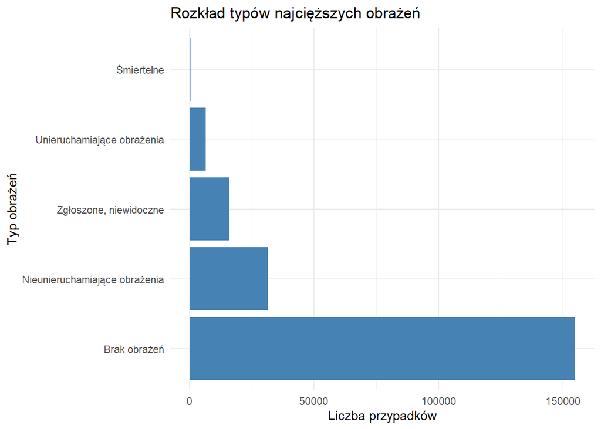

Większość przypadków to „brak obrażeń” lub „nieunieruchamiające obrażenia”. Klasy poważniejsze (np. śmiertelne) są znacznie rzadsze, co potwierdza silną nierównowagę klas.

## 25 najczęstszych przyczyn wypadków

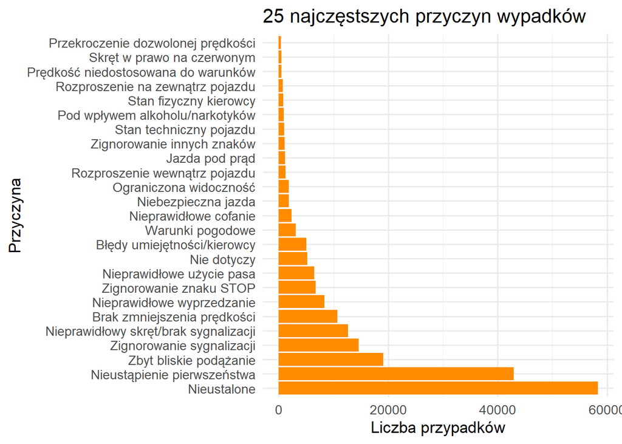

Najczęściej występujące przyczyny to błędy kierowców, takie jak „nieustąpienie pierwszeństwa” czy „zbyt bliskie podążanie”. Wskazuje to na potrzebę działań edukacyjnych i prewencyjnych.

## Liczba pojazdów a obrażenia

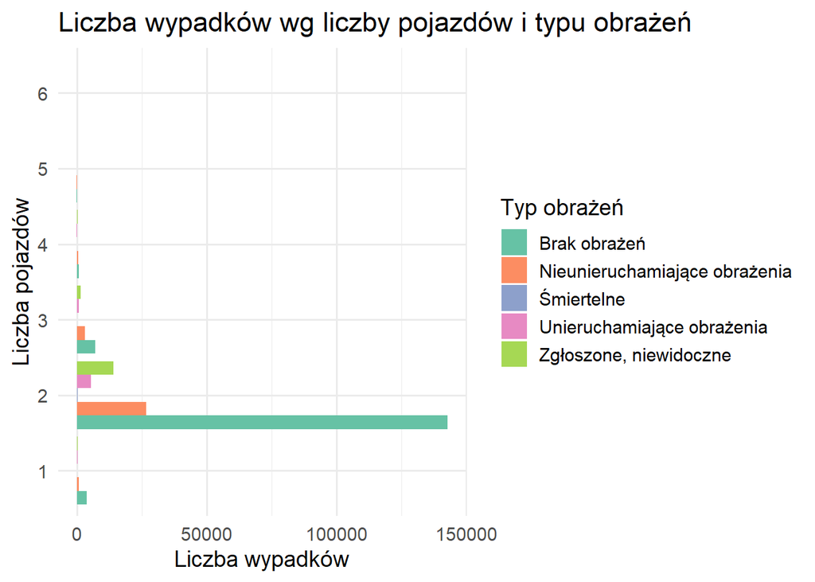

Najwięcej wypadków dotyczy 2 pojazdów. Wraz ze wzrostem liczby pojazdów nie widać jednoznacznego wzrostu powagi obrażeń.

## Warunki pogodowe i oświetlenia

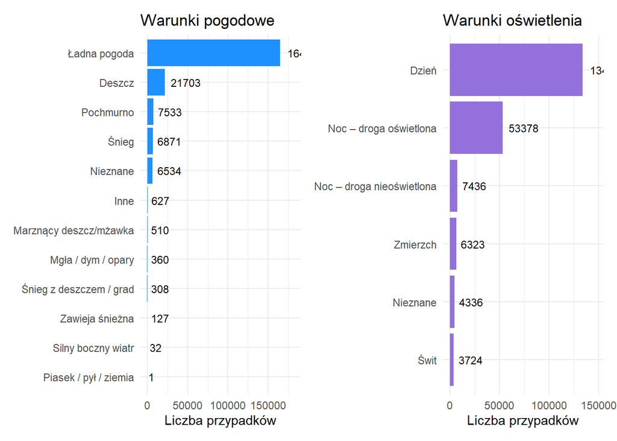

Większość wypadków ma miejsce przy dobrej pogodzie i w ciągu dnia. Wbrew intuicji, złe warunki pogodowe stanowią mniejszość – co może wynikać z większego ruchu w dobrych warunkach lub większej ostrożności kierowców podczas niesprzyjającej pogody.

## Wypadki wg dnia tygodnia i godziny

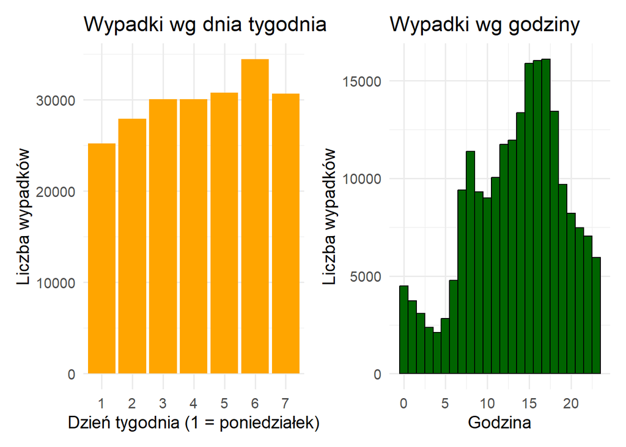

## Zakres szkód materialnych

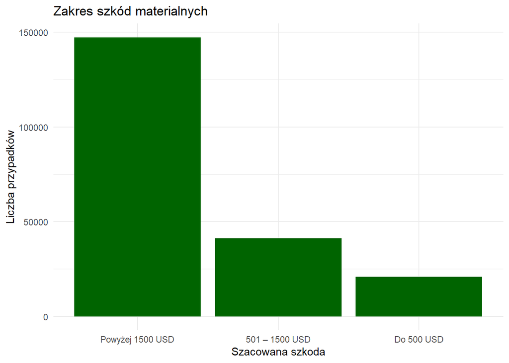

Zdecydowana większość wypadków kończy się szkodą powyżej 1500 USD. Oznacza to, że nawet przy lekkich obrażeniach straty finansowe są istotne.

## Porównanie obrażeń względem warunków

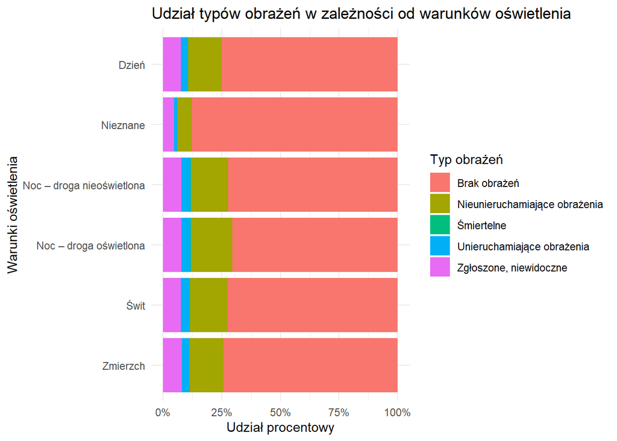

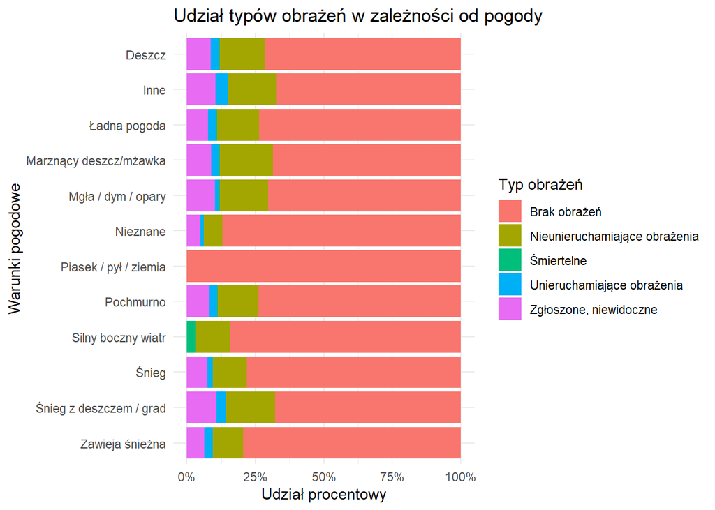

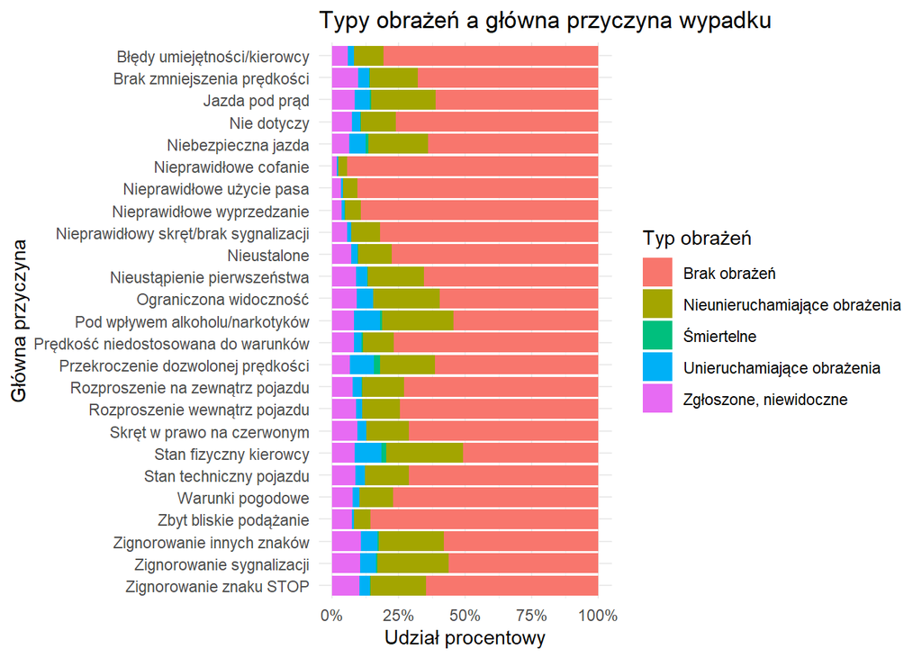

## Korelacje zmiennych numerycznych

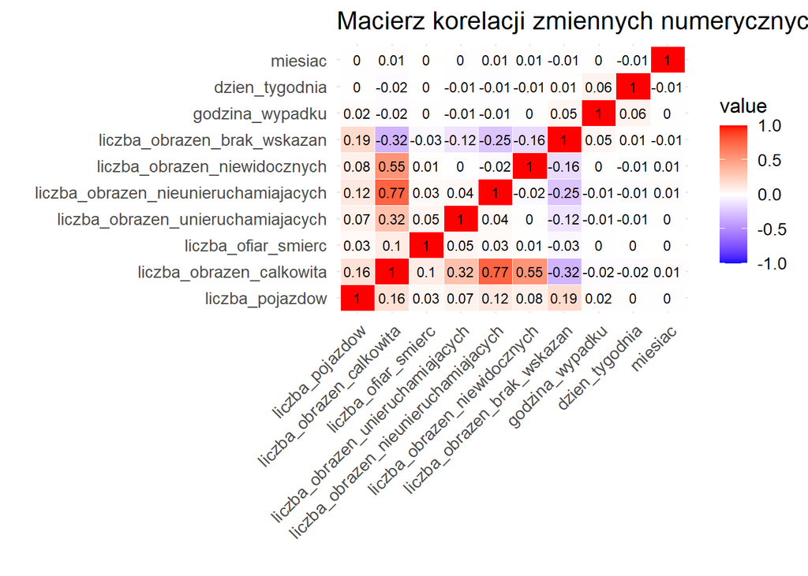

Macierz korelacji nie ujawnia silnych powiązań liniowych między większością zmiennych liczbowych - żaden ze współczynników nie przekracza wartości |0.8|. To dobra wiadomość z perspektywy dalszego modelowania, ponieważ brak silnych korelacji oznacza, że nie występuje problem współliniowości, który mógłby zaburzać działanie modeli predykcyjnych.

# Czyszczenie danych i wstępna selekcja cech

```
## Nie znaleziono zmiennych o zerowej wariancji.
```

```
## Brak silnych korelacji (> 0.8) — nie usuwano żadnych zmiennych.
```

```
## Dane kompletne — brak potrzeby imputacji.
```

W ramach wstępnego przygotowania danych sprawdzono:

**Zmienność cech** - nie znaleziono zmiennych o zerowej wariancji. Oznacza to, że wszystkie cechy zawierają wystarczającą różnorodność informacji, by mogły być użyteczne w predykcji.

**Współliniowość zmiennych liczbowych** - nie wykryto silnych korelacji (żaden współczynnik nie przekroczył progu |0.8|). Brak współliniowości eliminuje ryzyko powielenia informacji w modelu i wskazuje, że nie ma potrzeby usuwania żadnych zmiennych liczbowych.

**Braki danych** - zbiór danych jest kompletny. Nie stwierdzono braków wymagających imputacji.

W związku z powyższym, nie było potrzeby dokonywania redukcji cech ani uzupełniania danych - zbiór jest gotowy do dalszego etapu modelowania.

# Przygotowanie danych do modelowania

## Podział danych

```
## Wielkość zbioru treningowego: 167444
```

```
## Wielkość zbioru testowego: 41862
```

```
## Rozkład klas w zbiorze treningowym (procentowo):
```

```
##
##                  Brak obrażeń Nieunieruchamiające obrażenia
##                         73.94                         15.07
##                    Śmiertelne    Unieruchamiające obrażenia
##                          0.16                          3.15
##        Zgłoszone, niewidoczne
##                          7.67
```

```
##
## Rozkład klas w zbiorze testowym (procentowo):
```

```
##
##                  Brak obrażeń Nieunieruchamiające obrażenia
##                         74.02                         15.02
##                    Śmiertelne    Unieruchamiające obrażenia
##                          0.18                          3.07
##        Zgłoszone, niewidoczne
##                          7.71
```

Wyniki pokazują, że podział danych został przeprowadzony poprawnie i rozkład klas w zbiorze treningowym oraz testowym jest bardzo zbliżony. Oznacza to, że:

- Zbiór treningowy zawiera 167 444 przypadków, a testowy 41 862.
- Najliczniejsza klasa to „Brak obrażeń” (~74%), co potwierdza silną nierównowagę klas.
- Klasa „Śmiertelne” to zaledwie 0.16–0.18% przypadków, co czyni ją ekstremalnie rzadką i potencjalnie trudną do przewidzenia.

# Trening modeli na danych bazowych

```
## # A tibble: 3 × 3
##   Model                Accuracy    F1
##   <chr>                   <dbl> <dbl>
## 1 Regresja logistyczna     1    1.00
## 2 Random Forest            1.00 0.973
## 3 XGBoost                  1    1
```

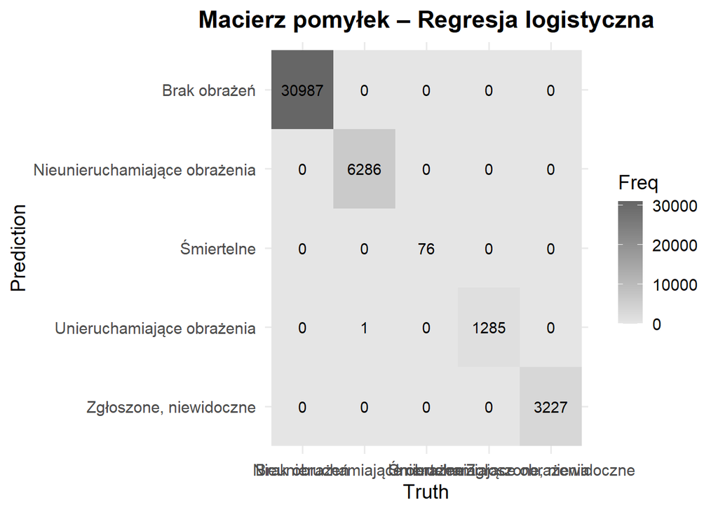

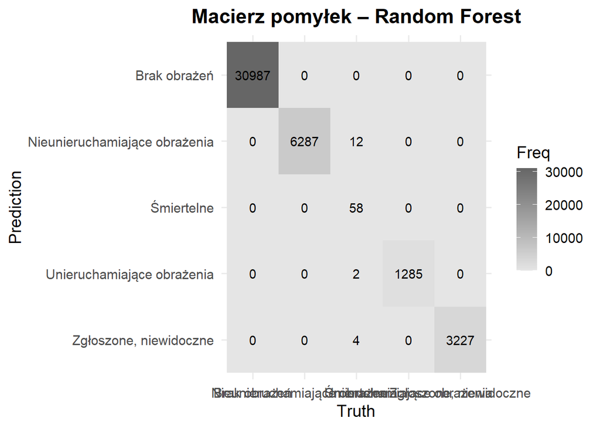

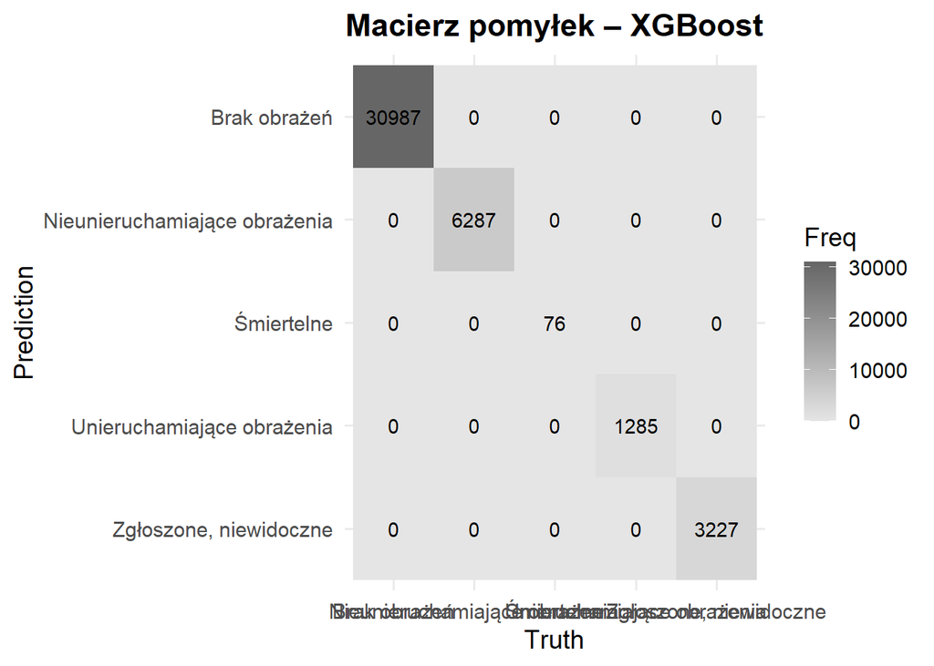

## Wyniki modeli klasyfikacyjnych – porównanie

### Random Forest

- Accuracy: 0.999
- F1-score: 0.973
- Wystąpiło kilka błędnych klasyfikacji.
- Nie wszystkie przypadki zostały zaklasyfikowane poprawnie w macierzy pomyłek.

### Podsumowanie

Wszystkie modele wykazały bardzo wysoką skuteczność, jednak XGBoost i regresja logistyczna osiągnęły niemal idealne wyniki.

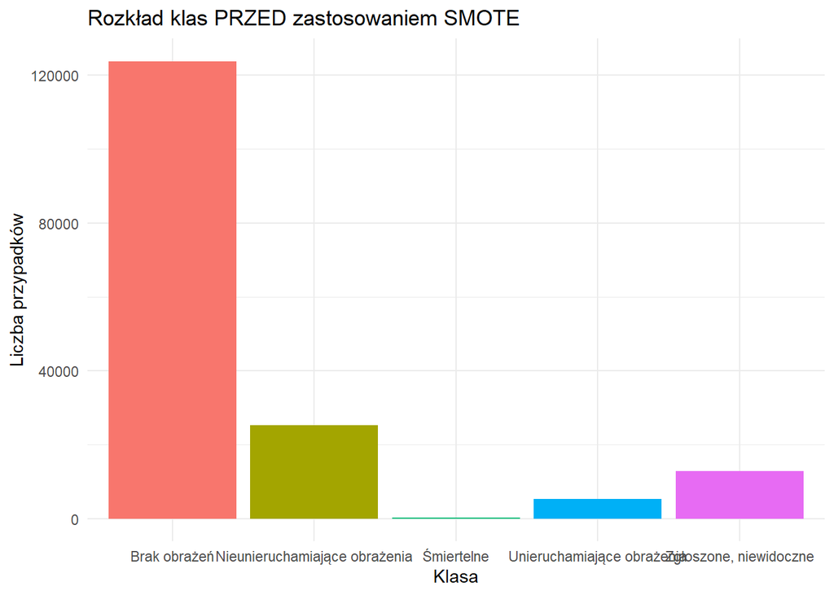

## Nierównowaga klas i jej wpływ na modele

W zbiorze danych występuje **silna nierównowaga klas**. Klasa „Brak obrażeń” stanowi zdecydowaną większość przypadków, podczas gdy pozostałe klasy – zwłaszcza „Śmiertelne” – są reprezentowane bardzo rzadko.

Taka dysproporcja może prowadzić do problemów podczas trenowania modeli klasyfikacyjnych. Modele uczone bez uwzględnienia balansu klas mają tendencję do faworyzowania klasy dominującej, co skutkuje niską czułością dla klas rzadkich.

W efekcie, metryki takie jak **accuracy** mogą być zawyżone i nie oddają rzeczywistej skuteczności modelu w rozróżnianiu między wszystkimi kategoriami obrażeń.

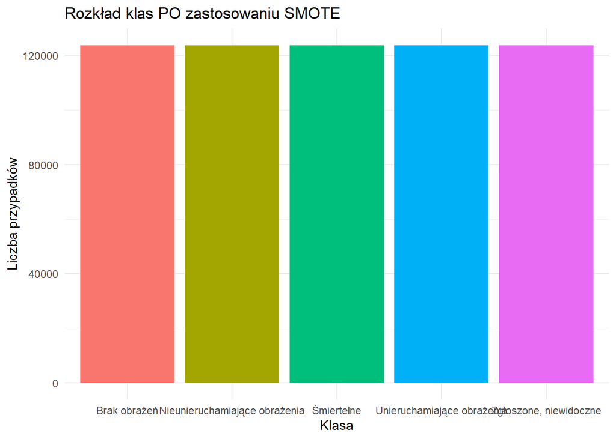

## Wnioski po zastosowaniu SMOTE

- Zastosowanie SMOTE skutecznie wyrównało liczność klas. Wszystkie kategorie obrażeń, w tym „Śmiertelne” i „Unieruchamiające obrażenia”, zostały wzmocnione syntetycznymi obserwacjami, co zredukowało pierwotną nierównowagę.
- Zbalansowany zbiór umożliwia skuteczniejsze wykrywanie rzadkich przypadków. Modele nie skupiają się już wyłącznie na klasie dominującej, lecz uczą się rozpoznawać także mniej liczne typy obrażeń.
- Wyrównanie liczebności może przełożyć się na wyższe wartości F1-score dla wcześniej niedoreprezentowanych klas, co poprawia równowagę klasyfikacji między kategoriami.
- Balansowanie może prowadzić do niewielkiego spadku ogólnej accuracy, ponieważ model nie koncentruje się już głównie na najczęstszej klasie. Jest to jednak akceptowalny kompromis, jeśli celem jest poprawa skuteczności dla wszystkich klas, a nie tylko tej dominującej.

# Trening modeli po zastosowaniu SMOTE

```
## # A tibble: 3 × 3
##   Model                        Accuracy    F1
##   <chr>                           <dbl> <dbl>
## 1 Regresja logistyczna (SMOTE)    0.999 0.994
## 2 Random Forest (SMOTE)           1.00  0.996
## 3 XGBoost (SMOTE)                 1     1
```

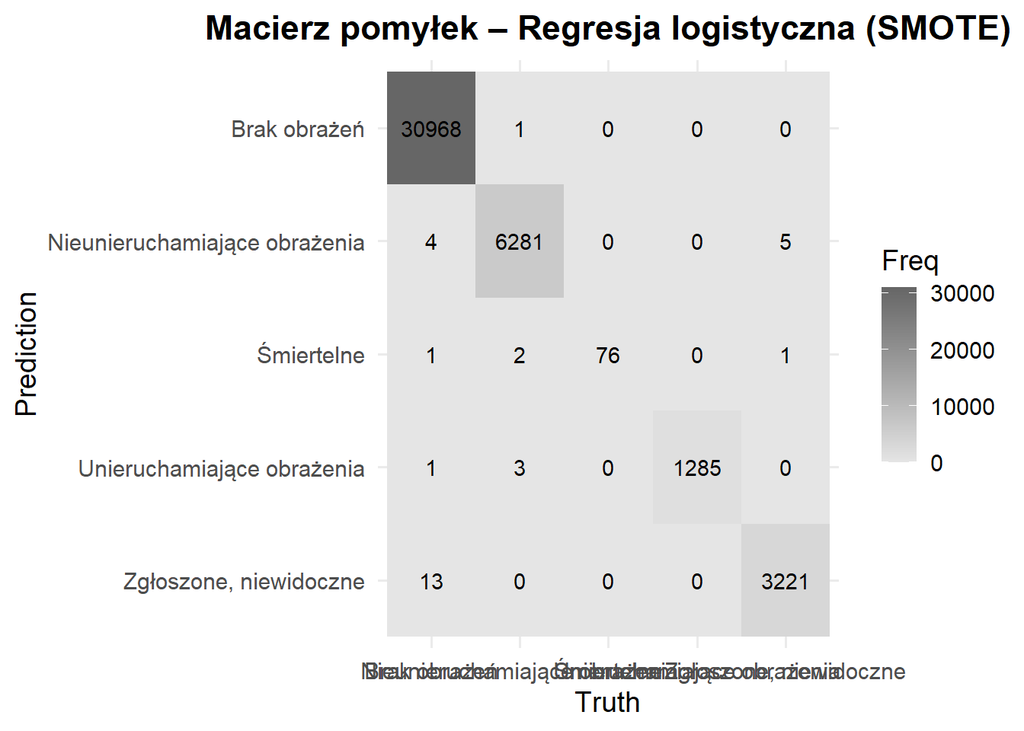

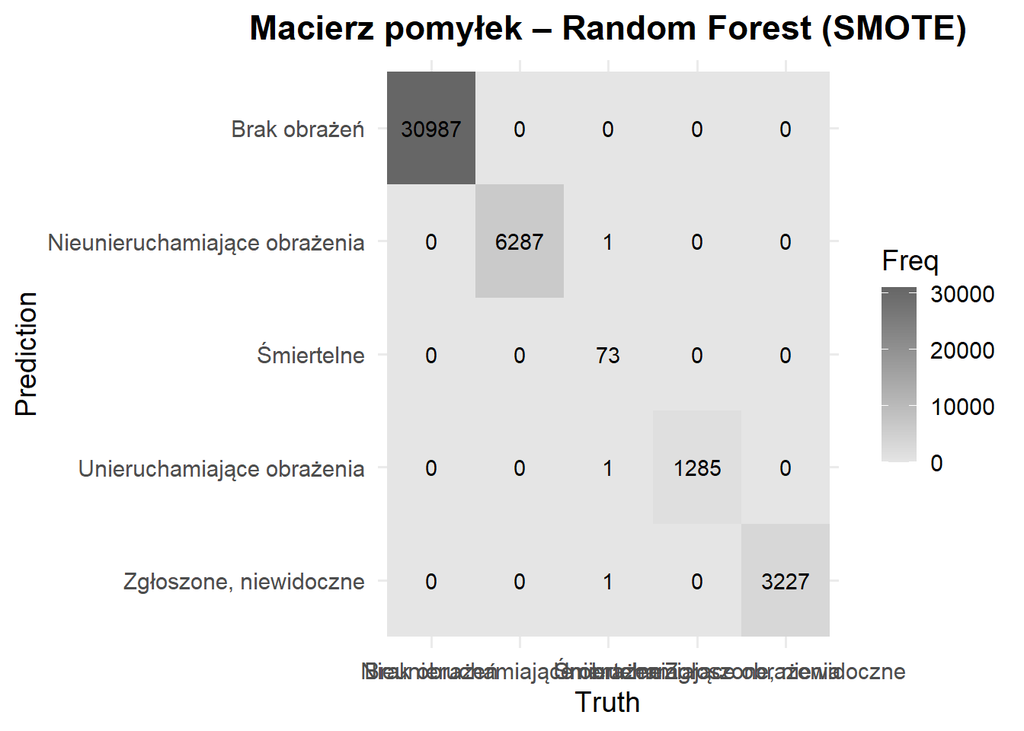

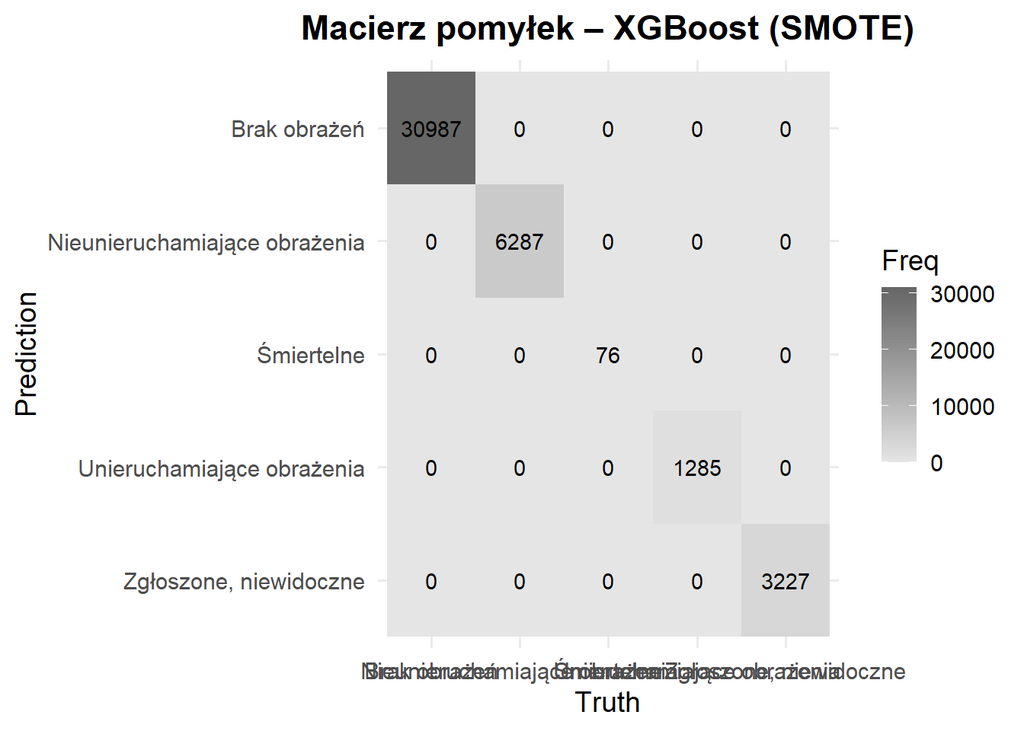

## Wyniki modeli po zastosowaniu SMOTE - porównanie

**XGBoost (SMOTE)**

- Accuracy: 1
- F1-score (macro): 1
- Wszystkie przypadki zostały zaklasyfikowane poprawnie.
- Brak błędów w macierzy pomyłek.

**Random Forest (SMOTE)**

- Accuracy: 0.999
- F1-score (macro): 0.996
- Wystąpiło kilka błędnych klasyfikacji.
- Nie wszystkie przypadki zostały zaklasyfikowane poprawnie w macierzy pomyłek.

**Regresja logistyczna (SMOTE)**

- Accuracy: 0.999
- F1-score (macro): 0.994
- Wystąpiło kilka błędnych klasyfikacji.
- Nie wszystkie przypadki zostały zaklasyfikowane poprawnie w macierzy pomyłek.

# Trening modeli po zastosowaniu undersamplingu

```
## # A tibble: 3 × 3
##   Model                 Accuracy    F1
##   <chr>                    <dbl> <dbl>
## 1 LogReg (Under)           0.973 0.845
## 2 Random Forest (Under)    0.997 0.985
## 3 XGBoost (Under)          1     1
```

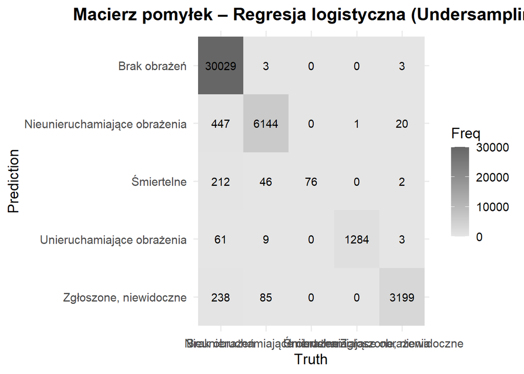

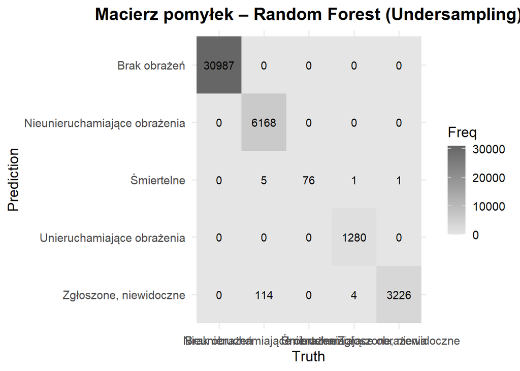

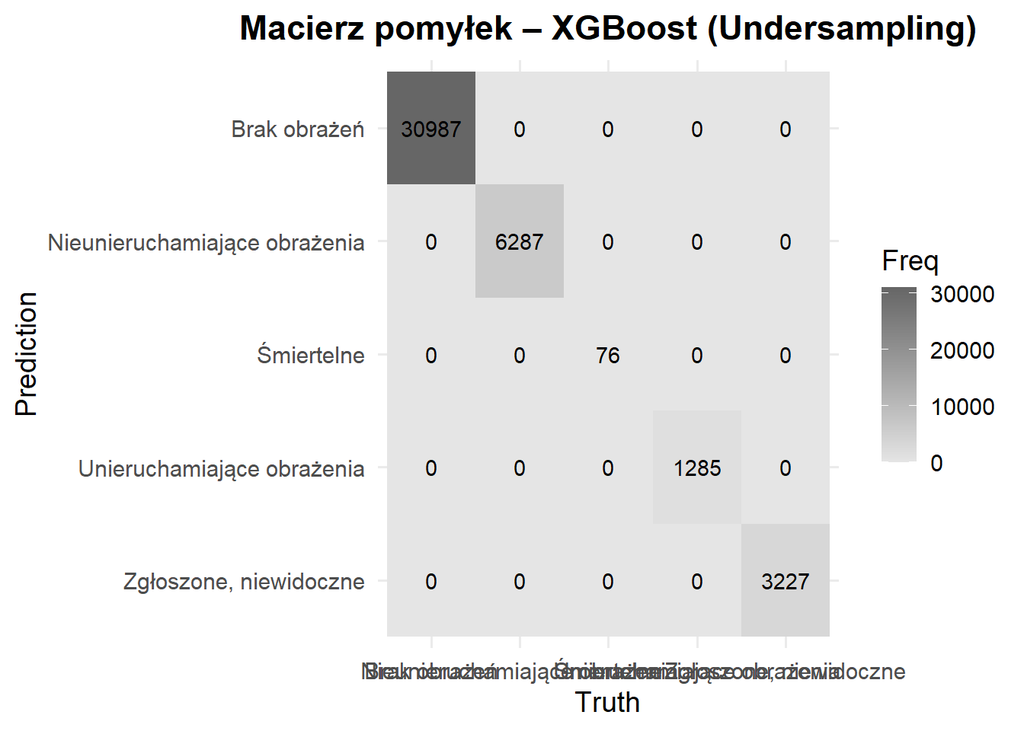

## Wyniki modeli po zastosowaniu undersamplingu - porównanie

**XGBoost (undersampling)**

- Accuracy: 1
- F1-score (macro): 1
- Wszystkie przypadki zostały zaklasyfikowane poprawnie.
- Brak błędów w macierzy pomyłek.

**Random Forest (undersampling)**

- Accuracy: 0.997
- F1-score (macro): 0.985
- Wystąpiło kilka błędnych klasyfikacji.
- Nie wszystkie przypadki zostały zaklasyfikowane poprawnie w macierzy pomyłek.

**Regresja logistyczna (undersampling)**

- Accuracy: 0.973
- F1-score (macro): 0.845
- Wystąpiło kilka błędnych klasyfikacji.
- Nie wszystkie przypadki zostały zaklasyfikowane poprawnie w macierzy pomyłek.

### Podsumowanie

Undersampling poprawił rozpoznawalność klas rzadkich, jednak działa gorzej niż SMOTE.

- **XGBoost** okazał się najskuteczniejszym modelem, łączącym prostotę undersamplingu z wysoką precyzją predykcji – także dla najrzadszych klas.
- **Random Forest** osiągnął bardzo dobre wyniki, choć nieco gorsze niż XGBoost.
- **Regresja logistyczna** wypada najsłabiej – zwłaszcza w klasyfikacji rzadkich zdarzeń i nie radzi sobie dobrze z bardziej złożonymi strukturami danych.

XGBoost pozostaje najlepszym modelem również po zastosowaniu undersamplingu.

# Tuning – XGBoost na oryginalnych danych

```
## Najlepsze parametry według Accuracy:
```

```
## # A tibble: 1 × 4
##    mtry min_n learn_rate .config
##   <int> <int>      <dbl> <chr>
## 1     7     2       1.25 Preprocessor1_Model01
```

```
##
## Najlepsze parametry według F1 (macro):
```

```
## # A tibble: 1 × 4
##    mtry min_n learn_rate .config
##   <int> <int>      <dbl> <chr>
## 1     7     2       1.25 Preprocessor1_Model01
```

```
## # A tibble: 20 × 9
##     mtry min_n learn_rate .metric  .estimator  mean     n    std_err .config
##    <int> <int>      <dbl> <chr>    <chr>      <dbl> <int>      <dbl> <chr>
##  1     7     2       1.25 accuracy multiclass 1.00      5 0.00000731 Preprocess…
##  2     7     2       1.25 f_meas   macro      0.999     5 0.000417   Preprocess…
##  3     7     9       1.58 accuracy multiclass 1.00      5 0.0000223  Preprocess…
##  4     7     9       1.58 f_meas   macro      0.996     5 0.00156    Preprocess…
##  5     8    18       1.02 accuracy multiclass 1.00      5 0.0000164  Preprocess…
##  6     8    18       1.02 f_meas   macro      0.998     5 0.00116    Preprocess…
##  7    10     3       1.59 accuracy multiclass 1.00      5 0.0000119  Preprocess…
##  8    10     3       1.59 f_meas   macro      0.999     5 0.000894   Preprocess…
##  9     3    13       1.03 accuracy multiclass 1.00      5 0.0000267  Preprocess…
## 10     3    13       1.03 f_meas   macro      0.996     5 0.00193    Preprocess…
## 11     3     8       1.37 accuracy multiclass 1.00      5 0.0000453  Preprocess…
## 12     3     8       1.37 f_meas   macro      0.997     5 0.00292    Preprocess…
## 13    12    16       1.24 accuracy multiclass 1.00      5 0.0000112  Preprocess…
## 14    12    16       1.24 f_meas   macro      0.998     5 0.000719   Preprocess…
## 15    15    20       1.77 accuracy multiclass 1.00      5 0.0000112  Preprocess…
## 16    15    20       1.77 f_meas   macro      0.997     5 0.000916   Preprocess…
## 17    15    18       1.85 accuracy multiclass 0.945     5 0.0516     Preprocess…
## 18    15    18       1.85 f_meas   macro      0.924     5 0.0465     Preprocess…
## 19    15    20       1.15 accuracy multiclass 1.00      5 0.0000219  Preprocess…
## 20    15    20       1.15 f_meas   macro      0.998     5 0.00129    Preprocess…
```

Ten sam zestaw hiperparametrów okazał się najlepszy zarówno pod względem accuracy, jak i F1-score, co świadczy o jego wysokiej stabilności i skuteczności.  
Wybrana konfiguracja:  
- `mtry = 7`  
- `min_n = 2`  
- `learn_rate ≈ 1.25`

Model z tym zestawem osiągał niemal idealne wyniki (średnia Accuracy i F1-score ≈ 1.00) w 5-krotnej walidacji krzyżowej, co wskazuje na bardzo dobre dopasowanie i wysoką jakość klasyfikacji – również dla klas rzadkich.

Większość alternatywnych kombinacji hiperparametrów dawała bardzo zbliżone wyniki (np. Accuracy: 0.999, 0.996), co świadczy o stabilności modelu.  
Najgorsze rezultaty uzyskano dla zestawu `mtry = 15`, `min_n = 18`, gdzie Accuracy spadło do 0.945.

- Odpowiedni dobór hiperparametrów ma istotny wpływ na skuteczność modelu.
- Wybrany zestaw parametrów pozwala osiągnąć bardzo wysoką skuteczność bez konieczności modyfikacji danych (SMOTE/undersampling).
- Wyniki walidacji krzyżowej są spójne i wysokie, co świadczy o stabilności rozwiązania i dobrej zdolności generalizacji modelu.

# Tuning – XGBoost po SMOTE

```
## # A tibble: 20 × 9
##     mtry min_n learn_rate .metric  .estimator  mean     n    std_err .config
##    <int> <int>      <dbl> <chr>    <chr>      <dbl> <int>      <dbl> <chr>
##  1     7     2       1.25 accuracy multiclass 1         5 0          Preprocess…
##  2     7     2       1.25 f_meas   macro      1         5 0          Preprocess…
##  3     7     9       1.58 accuracy multiclass 1         5 0          Preprocess…
##  4     7     9       1.58 f_meas   macro      1         5 0          Preprocess…
##  5     8    18       1.02 accuracy multiclass 1         5 0          Preprocess…
##  6     8    18       1.02 f_meas   macro      1         5 0          Preprocess…
##  7    10     3       1.59 accuracy multiclass 1         5 0          Preprocess…
##  8    10     3       1.59 f_meas   macro      1         5 0          Preprocess…
##  9     3    13       1.03 accuracy multiclass 1         5 0          Preprocess…
## 10     3    13       1.03 f_meas   macro      1         5 0          Preprocess…
## 11     3     8       1.37 accuracy multiclass 1.00      5 0.00000162 Preprocess…
## 12     3     8       1.37 f_meas   macro      1.00      5 0.00000162 Preprocess…
## 13    12    16       1.24 accuracy multiclass 1         5 0          Preprocess…
## 14    12    16       1.24 f_meas   macro      1         5 0          Preprocess…
## 15    15    20       1.77 accuracy multiclass 1.00      5 0.00000198 Preprocess…
## 16    15    20       1.77 f_meas   macro      1.00      5 0.00000198 Preprocess…
## 17    15    18       1.85 accuracy multiclass 0.988     5 0.0118     Preprocess…
## 18    15    18       1.85 f_meas   macro      0.988     5 0.0118     Preprocess…
## 19    15    20       1.15 accuracy multiclass 1         5 0          Preprocess…
## 20    15    20       1.15 f_meas   macro      1         5 0          Preprocess…
```

```
## Najlepsze parametry według Accuracy (SMOTE):
```

```
## # A tibble: 1 × 4
##    mtry min_n learn_rate .config
##   <int> <int>      <dbl> <chr>
## 1     7     2       1.25 Preprocessor1_Model01
```

```
##
## Najlepsze parametry według F1 (macro) (SMOTE):
```

```
## # A tibble: 1 × 4
##    mtry min_n learn_rate .config
##   <int> <int>      <dbl> <chr>
## 1     7     2       1.25 Preprocessor1_Model01
```

Ten sam zestaw parametrów co na danych oryginalnych (mtry = 7, min_n = 2, learn_rate ≈ 1.25) uzyskał najlepsze wyniki również po zastosowaniu SMOTE.  
To wskazuje na jego uniwersalność i stabilność niezależnie od sposobu przetworzenia danych.

Model osiągnął perfekcyjne metryki, zarówno pod względem ogólnej skuteczności, jak i równowagi między klasami (F1 macro = 1).  
Potwierdza to, że SMOTE skutecznie poprawił wykrywalność rzadkich klas, co w połączeniu z odpowiednim tuningiem parametrów daje optymalny efekt.

Inne kombinacje z siatki również dawały bardzo wysokie wyniki (np. 0.98).  
Brak istotnych spadków metryk w obrębie zakresów parametrów świadczy o dużej stabilności modelu.

# Tuning – XGBoost po undersamplingu

```
## # A tibble: 20 × 9
##     mtry min_n learn_rate .metric  .estimator  mean     n  std_err .config
##    <int> <int>      <dbl> <chr>    <chr>      <dbl> <int>    <dbl> <chr>
##  1     7     2       1.25 accuracy multiclass 0.999     5 0.000727 Preprocessor…
##  2     7     2       1.25 f_meas   macro      0.999     5 0.000727 Preprocessor…
##  3     7     9       1.58 accuracy multiclass 0.996     5 0.00199  Preprocessor…
##  4     7     9       1.58 f_meas   macro      0.996     5 0.00199  Preprocessor…
##  5     8    18       1.02 accuracy multiclass 0.995     5 0.00247  Preprocessor…
##  6     8    18       1.02 f_meas   macro      0.995     5 0.00247  Preprocessor…
##  7    10     3       1.59 accuracy multiclass 1         5 0        Preprocessor…
##  8    10     3       1.59 f_meas   macro      1         5 0        Preprocessor…
##  9     3    13       1.03 accuracy multiclass 1         5 0        Preprocessor…
## 10     3    13       1.03 f_meas   macro      1         5 0        Preprocessor…
## 11     3     8       1.37 accuracy multiclass 0.998     5 0.000891 Preprocessor…
## 12     3     8       1.37 f_meas   macro      0.998     5 0.000891 Preprocessor…
## 13    12    16       1.24 accuracy multiclass 0.995     5 0.00218  Preprocessor…
## 14    12    16       1.24 f_meas   macro      0.995     5 0.00218  Preprocessor…
## 15    15    20       1.77 accuracy multiclass 0.990     5 0.00313  Preprocessor…
## 16    15    20       1.77 f_meas   macro      0.990     5 0.00312  Preprocessor…
## 17    15    18       1.85 accuracy multiclass 0.995     5 0.00272  Preprocessor…
## 18    15    18       1.85 f_meas   macro      0.995     5 0.00272  Preprocessor…
## 19    15    20       1.15 accuracy multiclass 0.996     5 0.000727 Preprocessor…
## 20    15    20       1.15 f_meas   macro      0.996     5 0.000728 Preprocessor…
```

```
## Najlepsze parametry (undersampling – Accuracy):
```

```
## # A tibble: 1 × 4
##    mtry min_n learn_rate .config
##   <int> <int>      <dbl> <chr>
## 1    10     3       1.59 Preprocessor1_Model04
```

```
##
## Najlepsze parametry (undersampling – F1):
```

```
## # A tibble: 1 × 4
##    mtry min_n learn_rate .config
##   <int> <int>      <dbl> <chr>
## 1    10     3       1.59 Preprocessor1_Model04
```

Dla obu metryk (Accuracy i F1) najlepsze wyniki uzyskano przy konfiguracji:

- `mtry = 10`  
- `min_n = 3`  
- `learn_rate ≈ 1.59`

Parametry te zapewniły wysoką skuteczność klasyfikacji, mimo zmniejszonej liczby obserwacji w zbiorze po undersamplingu.

Model osiągnął perfekcyjne wyniki również na danych zbalansowanych poprzez undersampling.  
Oznacza to, że mimo redukcji danych, XGBoost potrafił uchwycić strukturę zbioru i klasyfikować przypadki bezbłędnie.

Zestawy takie jak `mtry = 7`, `min_n = 2` dawały bardzo dobre wyniki (ok. 0.999). Wzrost wartości `min_n` i `learn_rate` prowadził do lekkiego spadku skuteczności np. dla `mtry = 15`, `min_n = 20` Accuracy spadało do ok. 0.990.

- Undersampling nie pogorszył skuteczności modelu – przeciwnie, XGBoost poradził sobie bardzo dobrze mimo ograniczonego zbioru.
- Optymalne hiperparametry różnią się od tych z danych oryginalnych i po SMOTE, co potwierdza wpływ sposobu balansu klas na tuning.
- XGBoost po undersamplingu osiąga wyniki porównywalne do tych uzyskanych na danych po SMOTE lub oryginalnych, ale przy niższym koszcie obliczeniowym.

# Finalizacja modeli XGBoost po tuningu

```
## # A tibble: 3 × 3
##   Model                   Accuracy    F1
##   <chr>                      <dbl> <dbl>
## 1 XGBoost – oryginalne       1     1
## 2 XGBoost – SMOTE            0.969 0.957
## 3 XGBoost – undersampling    0.999 0.997
```

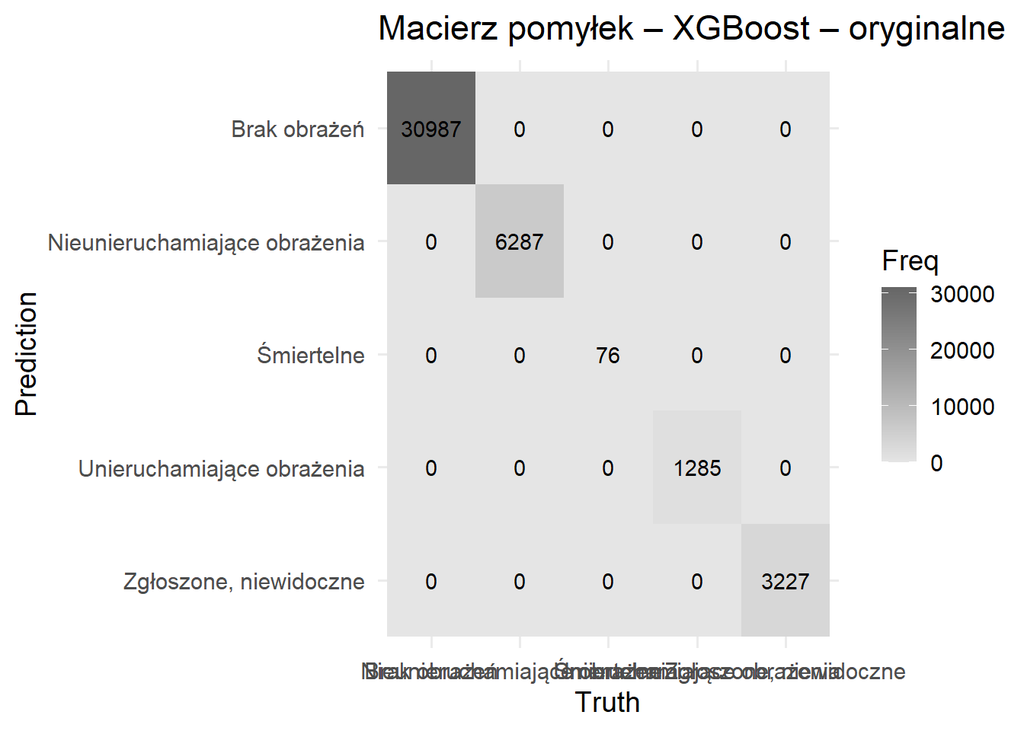

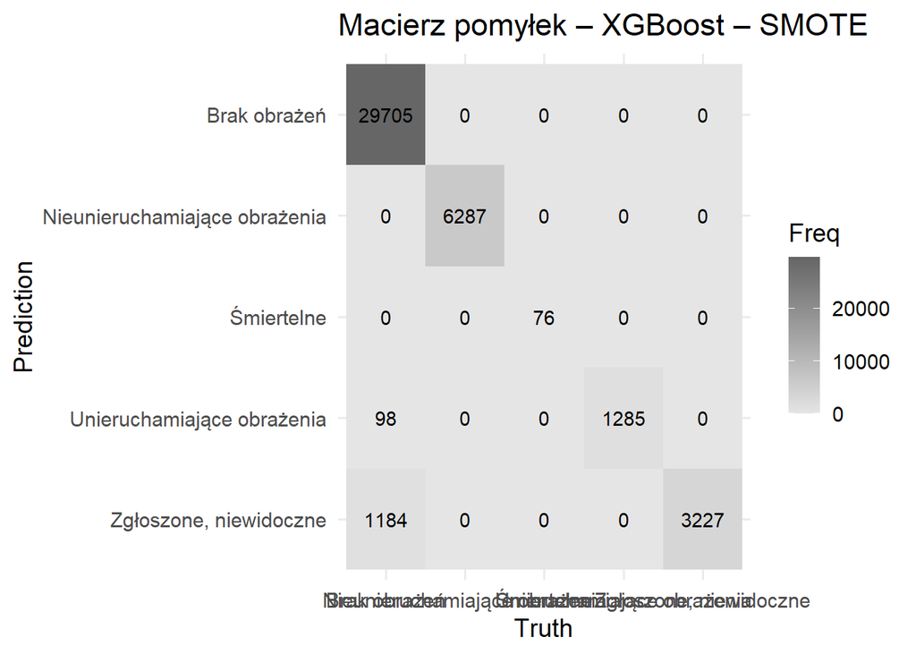

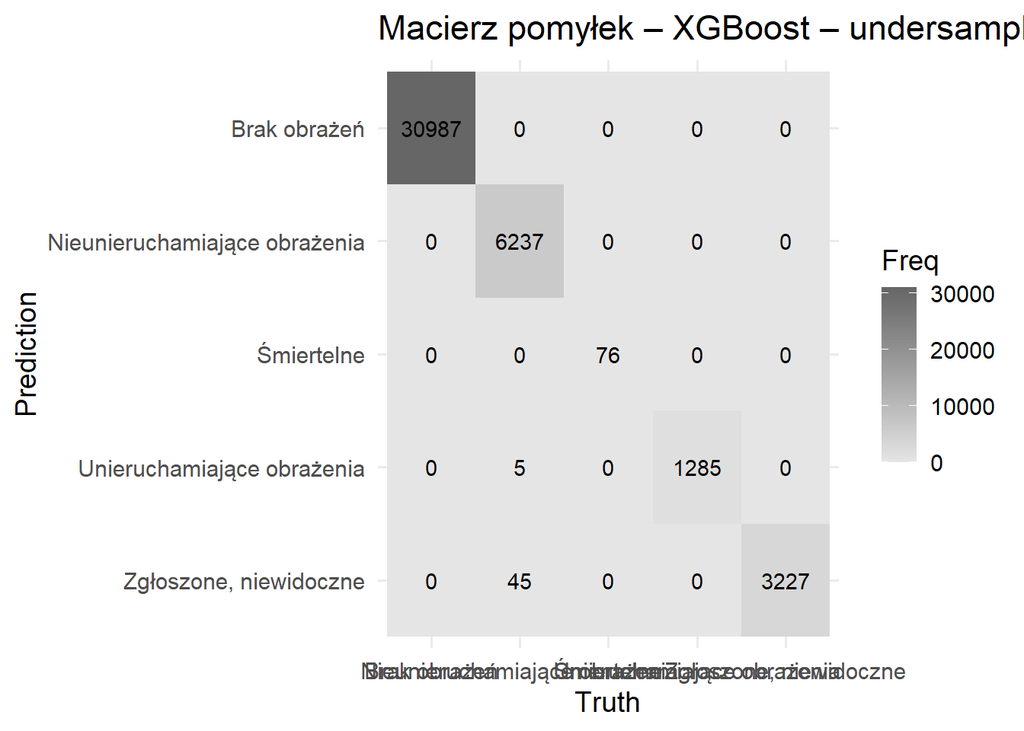

Model **XGBoost po tuningu na danych oryginalnych** zapewnia najwyższą skuteczność spośród wszystkich testowanych wariantów. Osiągnął perfekcyjne wyniki:

- **Accuracy:** 1
- **F1-score:** 1
- **Macierz pomyłek:** brak błędów klasyfikacji we wszystkich klasach.

Model ten zachowuje pełną informację zawartą w danych, nie wymaga przetwarzania (SMOTE, undersampling) i wykazuje wyjątkową stabilność.

## Podsumowanie projektu

Celem analizy było zbudowanie modelu predykcyjnego, który na podstawie danych o warunkach i okolicznościach wypadku drogowego przewiduje, jaki typ najcięższych obrażeń odniosą jego uczestnicy. Problem został sformułowany jako klasyfikacja wieloklasowa, a zmienną celu była kategoria `najciezsze_obrazenia`.

### Wykonane kroki:

**Eksploracja danych (EDA):**  
Przeanalizowano rozkład zmiennych liczbowych i kategorycznych. Zidentyfikowano silną nierównowagę klas – dominacja klasy „Brak obrażeń”.

**Wizualizacje zależności:**  
Zbadano relacje między typem obrażeń, a warunkami pogodowymi, oświetleniem, liczbą pojazdów i przyczyną zdarzenia.

**Czyszczenie i przygotowanie danych:**  
Przeprowadzono kontrolę – nie wykryto zmiennych o zerowej wariancji, ani silnych korelacji.  
Zbiór danych był kompletny – brak braków danych.  
Przeprowadzono kodowanie zmiennych kategorycznych, normalizację predyktorów numerycznych, oraz usunięto kolumnę z datą zdarzenia.

**Balansowanie klas:**  
Zastosowano dwie techniki:  
- SMOTE – do syntetycznego powiększenia klas rzadkich  
- Undersampling – do redukcji klasy dominującej

**Uczenie modeli:**  
Przetestowano trzy algorytmy: regresję logistyczną, Random Forest i XGBoost.

**Tuning hiperparametrów:**  
Zastosowano 5-krotną walidację krzyżową i siatkę losową do dostrojenia parametrów XGBoost.

**Ewaluacja i porównanie:**  
Obliczono Accuracy i F1-score, przeanalizowano macierze pomyłek. Porównano wyniki modeli na danych oryginalnych, po SMOTE i po undersamplingu.

### Kluczowe wnioski:

Model **XGBoost trenowany na oryginalnych danych** z tuningiem hiperparametrów jest najbardziej efektywnym i stabilnym rozwiązaniem. Zapewnia najwyższą skuteczność klasyfikacji bez potrzeby dodatkowego przetwarzania zbioru.

Projekt potwierdza, że klasyfikacja najcięższych obrażeń w wypadkach drogowych, przy użyciu odpowiednio dobranych metod i modeli, może być bardzo skuteczna. Kluczowe znaczenie miały zarówno tuning, jak i świadome podejście do problemu nierównowagi klas.